# Notebook

### Web Information Retrieval and Data Mining - Assignment 3

```
Student: Mankevic, Karina (1036163)
```

#### Answer 1.1, Baseline (4p)

- Dense network, at least 3 layers, shaped like a pyramid
  - Last layer: 10 nodes, sigmoid.
  - Loss: categorical cross-entropy. Metric: accuracy
- No preprocessing, regularization. Get at least 70% accuracy.
- Explain design decisions. Discuss performance.
  - Does it overfit (large/growing gap between loss and val_loss)?

[output not shown]

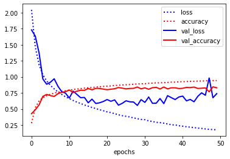

```
Model: "sequential_9"
_________________________________________________________________
Layer (type)                 Output Shape              Param #
=================================================================
reshape_9 (Reshape)          (None, 3072)              0
_________________________________________________________________
dense_52 (Dense)             (None, 1528)              4695544
_________________________________________________________________
dense_53 (Dense)             (None, 756)               1155924
_________________________________________________________________
dense_54 (Dense)             (None, 370)               280090
_________________________________________________________________
dense_55 (Dense)             (None, 177)               65667
_________________________________________________________________
dense_56 (Dense)             (None, 80)                14240
_________________________________________________________________
dense_57 (Dense)             (None, 32)                2592
_________________________________________________________________
dense_58 (Dense)             (None, 10)                330
=================================================================
Total params: 6,214,387
Trainable params: 6,214,387
Non-trainable params: 0
_________________________________________________________________
None
def build_model_1_1():
  # The input layer consists of 3072 neurons
  # Let n:= the number of neurons at the current layer
  # Then, every next layer consists of (n/2-8), except the last layer
  # The last layer consists of 10 neurons, as the network is trained to perform
  # categorial classification on 10 classes
  model = models.Sequential()
  # input layer:
  model.add(layers.Reshape((3072,), input_shape=(32,32,3)))
  # imtermediate layers:
  # n/2-8: 1528, 756, 370, 177, 80, 32, 10
  model.add(layers.Dense(1528, activation='relu'))
  model.add(layers.Dense(756, activation='relu'))
  model.add(layers.Dense(370, activation='relu'))
  model.add(layers.Dense(177, activation='relu'))
  model.add(layers.Dense(80, activation='relu'))
  model.add(layers.Dense(32, activation='relu'))
  # output layer:
  model.add(layers.Dense(10, activation='softmax'))
  model.compile(optimizer='SGD',
                loss='categorical_crossentropy',
                metrics=['accuracy'])
  return model
```

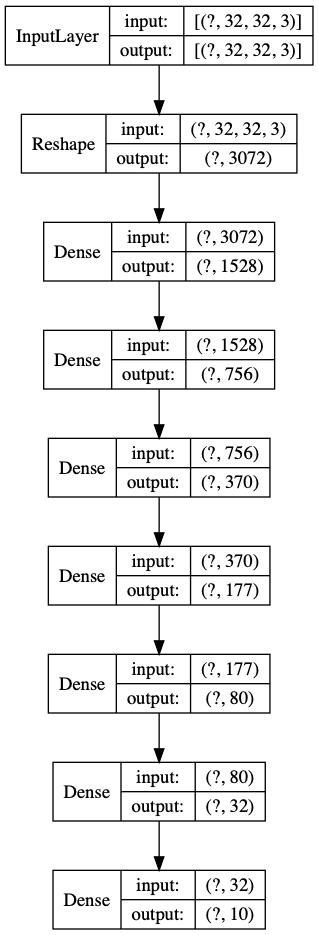

#### Answer 1.2, Preprocess (2p)

- Convert images to greyscale, other preprocessing optional.
  - Input shape should be (32,32,1)
- Explain design decisions. Is it better? Why (not)?
  - Color information is likely not so useful for classification. Greyscale makes the network smaller, less parameters to learn, less likely to overfit.

[output not shown]

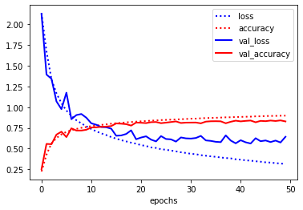

```
Model: "sequential_3"
_________________________________________________________________
Layer (type)                 Output Shape              Param #
=================================================================
reshape_3 (Reshape)          (None, 1024)              0
_________________________________________________________________
dense_11 (Dense)             (None, 504)               516600
_________________________________________________________________
dense_12 (Dense)             (None, 244)               123220
_________________________________________________________________
dense_13 (Dense)             (None, 114)               27930
_________________________________________________________________
dense_14 (Dense)             (None, 49)                5635
_________________________________________________________________
dense_15 (Dense)             (None, 17)                850
_________________________________________________________________
dense_16 (Dense)             (None, 10)                180
=================================================================
Total params: 674,415
Trainable params: 674,415
Non-trainable params: 0
_________________________________________________________________
None
def build_model_1_2():
  # The input layer consists of 1024 neurons
  # Let n:= the number of neurons at the current layer
  # Then, every next layer consists of (n/2-8), except the last layer
  # The last layer consists of 10 neurons, as the network is trained to perform
  # categorial classification on 10 classes
  model = models.Sequential()
  # input layer:
  model.add(layers.Reshape((1024,), input_shape=(32,32,1)))
  # imtermediate layers:
  # n/2-8: 504, 244, 114, 49, 17, 10
  model.add(layers.Dense(504, activation='relu'))
  model.add(layers.Dense(244, activation='relu'))
  model.add(layers.Dense(114, activation='relu'))
  model.add(layers.Dense(49, activation='relu'))
  model.add(layers.Dense(17, activation='relu'))
  # output layer:
  model.add(layers.Dense(10, activation='softmax'))
  model.compile(optimizer='SGD',
                loss='categorical_crossentropy',
                metrics=['accuracy'])
  return model
```

#### Answer 1.3, Tune (4p)

- Regularize the model. What works best?
  - Should consider batch normalization, dropout, l1/l2 regularization (or Nesterov)
- Tune other hyperparameters (e.g. learning rate, batch size,...) as you see fit.
  - At least consider tuning learning rate, ideally also momentum, decay, other optimizers
- Explain your findings and final design decisions. Discuss the results.
  - Should be better, at least it shouldn't overfit

[output not shown]

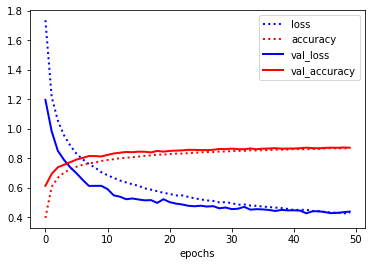

```
def build_model_1_3():
  model = models.Sequential()
  # input layer:
  model.add(layers.Reshape((1024,), input_shape=(32,32,1)))
  # intermediate layers:
  model.add(layers.BatchNormalization())
  model.add(layers.Dense(504, activation='relu'))
  model.add(layers.Dropout(0.2))
  model.add(layers.Dense(244, activation='relu'))
  model.add(layers.Dropout(0.2))
  model.add(layers.Dense(114, activation='relu'))
  model.add(layers.Dropout(0.2))
  model.add(layers.Dense(49, activation='relu'))
  model.add(layers.Dense(17, activation='relu'))
  # output layer:
  model.add(layers.Dense(10, activation='softmax'))

  sgd_opt = tf.keras.optimizers.SGD(learning_rate=0.1)
  model.compile(optimizer=sgd_opt,
                loss='categorical_crossentropy',
                metrics=['accuracy'])
  return model
```

#### Answer 2.1, ConvNet (7p)

- Build a sequential ConvNet, get at least 90% accuracy.
  - Conv2D layers, input shape (32,32,1)
  - Consider using blocks of Conv2D layers with maxpooling in between
  - Use zero-padding in Conv2D layers because the images are small
  - At least one dense hidden layer and dense output layer (sigmoid)
  - Consider adding batch normalization, dropout
  - Consider small dropout rates in beginning, larger dropout rates later in network
  - Consider other optimizers and tuning learning rate, momentum,...
- Explain what you did and why (800 chars). Is it working well?
  - Should be quite elaborate and sensible

[output not shown]

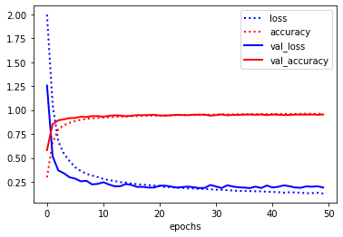

```
Model: "sequential_18"
_________________________________________________________________
Layer (type)                 Output Shape              Param #
=================================================================
conv2d_78 (Conv2D)           (None, 32, 32, 32)        320
_________________________________________________________________
batch_normalization_49 (Batc (None, 32, 32, 32)        128
_________________________________________________________________
conv2d_79 (Conv2D)           (None, 32, 32, 32)        9248
_________________________________________________________________
batch_normalization_50 (Batc (None, 32, 32, 32)        128
_________________________________________________________________
max_pooling2d_39 (MaxPooling (None, 16, 16, 32)        0
_________________________________________________________________
dropout_61 (Dropout)         (None, 16, 16, 32)        0
_________________________________________________________________
conv2d_80 (Conv2D)           (None, 16, 16, 64)        18496
_________________________________________________________________
batch_normalization_51 (Batc (None, 16, 16, 64)        256
_________________________________________________________________
conv2d_81 (Conv2D)           (None, 16, 16, 64)        36928
_________________________________________________________________
batch_normalization_52 (Batc (None, 16, 16, 64)        256
_________________________________________________________________
max_pooling2d_40 (MaxPooling (None, 8, 8, 64)          0
_________________________________________________________________
dropout_62 (Dropout)         (None, 8, 8, 64)          0
_________________________________________________________________
conv2d_82 (Conv2D)           (None, 8, 8, 128)         73856
_________________________________________________________________
batch_normalization_53 (Batc (None, 8, 8, 128)         512
_________________________________________________________________
conv2d_83 (Conv2D)           (None, 8, 8, 128)         147584
_________________________________________________________________
batch_normalization_54 (Batc (None, 8, 8, 128)         512
_________________________________________________________________
max_pooling2d_41 (MaxPooling (None, 4, 4, 128)         0
_________________________________________________________________
dropout_63 (Dropout)         (None, 4, 4, 128)         0
_________________________________________________________________
```

[output cut: 28 more lines]

```
  model.add(layers.BatchNormalization())
  model.add(layers.Conv2D(128, (3,3), padding='same', activation='relu'))
  model.add(layers.BatchNormalization())
  model.add(layers.MaxPooling2D((2, 2)))
  model.add(layers.Dropout(0.5))

  model.add(layers.Flatten())
  model.add(layers.Dense(128, activation='relu'))
  model.add(layers.Dropout(0.5))
  model.add(layers.Dense(10, activation='softmax'))
  sgd_opt = tf.keras.optimizers.SGD(learning_rate=0.1)
  model.compile(optimizer=sgd_opt,
                loss='categorical_crossentropy',
                metrics=['accuracy'])
  return model
```

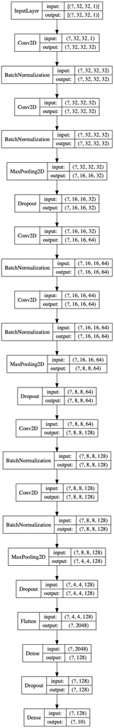

#### Answer 2.2, Data Augmentation (3p)

- Augment the preprocessed training data.
  - Use small variations (small shifts up-down, left-right) of flips becasue the images are small
  - Large shifts and rotations distort the image too much
- Explain what you did and why. Discuss the performance of the model.

[output not shown]

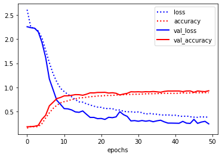

[output not shown]

#### Answer 3.1, Misclassifications (2p)

[output not shown]

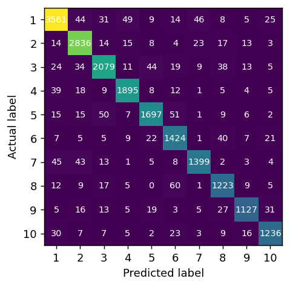

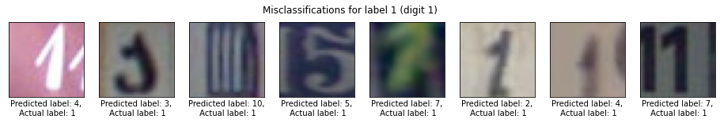

#### Answer 3.2, Activations (4p)

- Retrieve and visualize the activations for one example
- For every filter for different convolutional layers (at different depths in the network).
- Give an explanation. Is your model indeed learning something useful?
  - Should detect edges etc in first layers, higher-order object (e.g. interesting regions) in deeper layers.

[output not shown]

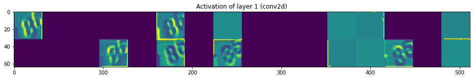

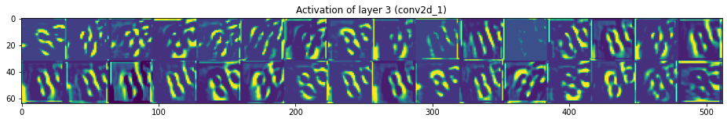

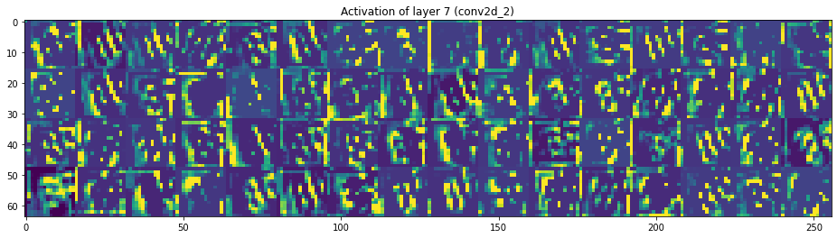

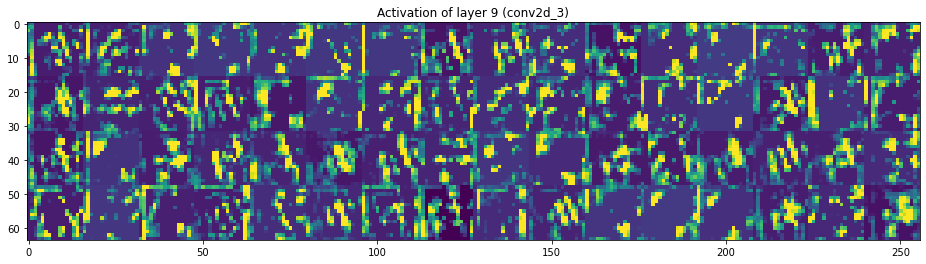

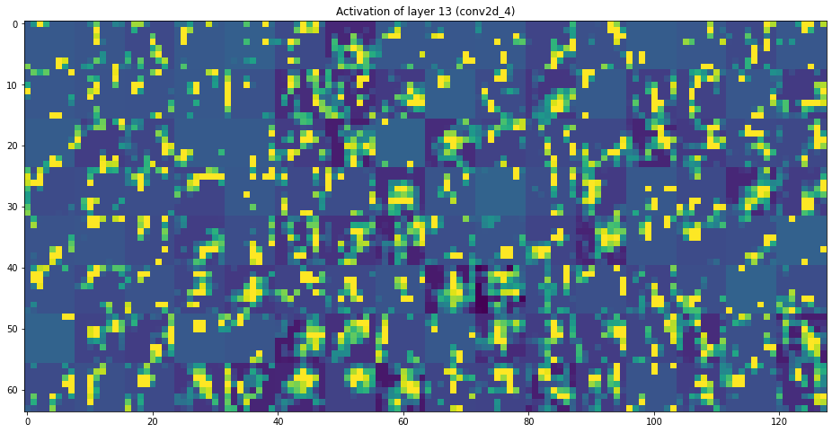

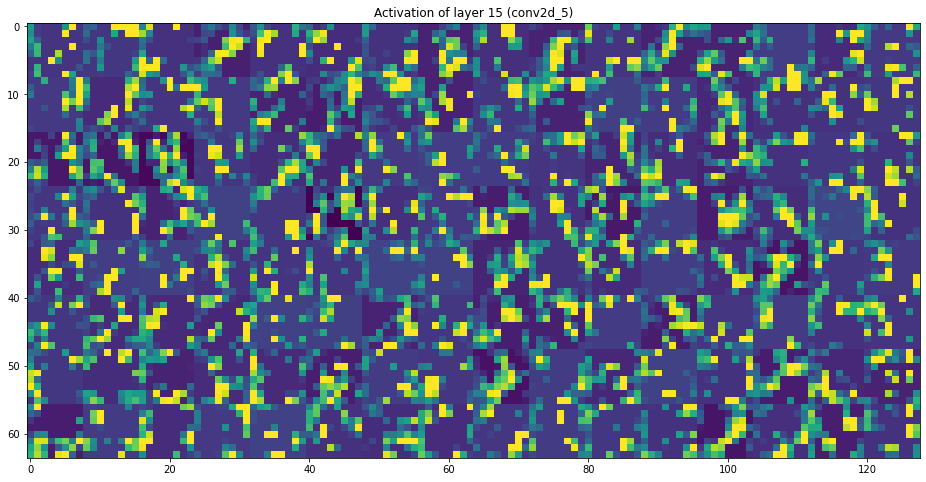

#### Answer 3.3, Class activation map (4p)

- Show a class activation map for your last convolutional layer
- Superimpose the activation map over the image, or plot side by side
  - Should make sense, detect interesting regions to classify the number

```
Predicted class: 8, Actual class: 8
def plot_activation_map():
  image_id = 0
  K.clear_session()
  model = load_model_from_file(base_dir, 'model_2_2')
  # Retrieve the picture:
  img_tensor_gray = X_test_gray[image_id]
  x = np.expand_dims(img_tensor_gray, axis=0)

  predict_class_index = np.argmax(y_pred[image_id])
  actual_class_index = np.argmax(y_test[image_id])
  print("Predicted class: {}, Actual class: {}".format(predict_class_index + 1, actual_class_index + 1))

  image_output = model.output[:,predict_class_index]

  # There is the output feature map of the conv layer,
  # the last convolutional layer in VGG16
  last_conv_layer = model.get_layer('conv2d_5')

  # This is the gradient of the class with regard to
  # the output feature map of `block5_conv3`
  grads = K.gradients(image_output, last_conv_layer.output)[0]

  # This is a vector, where each entry
  # is the mean intensity of the gradient over a specific feature map channel
  pooled_grads = K.mean(grads, axis=(0, 1, 2))

  # This function allows us to access the values of the quantities we just defined:
  # `pooled_grads` and the output feature map of last conv. layer,
  # given a sample image
  iterate = K.function([model.input], [pooled_grads, last_conv_layer.output[0]])

  # These are the values of these two quantities, as Numpy arrays,
  # given our sample image
  pooled_grads_value, conv_layer_output_value = iterate([x])

  # We multiply each channel in the feature map array
  # by "how important this channel is" with regard to the class
  for i in range(128):
      conv_layer_output_value[:, :, i] *= pooled_grads_value[i]

  # The channel-wise mean of the resulting feature map
  # is our heatmap of class activation
  heatmap = np.mean(conv_layer_output_value, axis=-1)

  preds = model.predict(x)

  heatmap = np.maximum(heatmap, 0) #avoid negative values
  if np.max(heatmap) > 0:
    heatmap /=  np.max(heatmap)

  # plt.matshow(heatmap)
  return heatmap
```

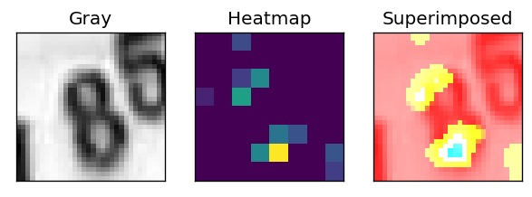

#### Answer 4.1, Fast feature extraction (5p)

- Import the VGG16 model, pretrained on ImageNet
- Freeze convolutional base, adds a dense layer
- Consider unfreezing the last few convolutional layers and evaluate whether that works better
  - Check if they do. It is very likely to help.
- Discuss the observed performance
  - Should get around 80% accuracy

[output not shown]

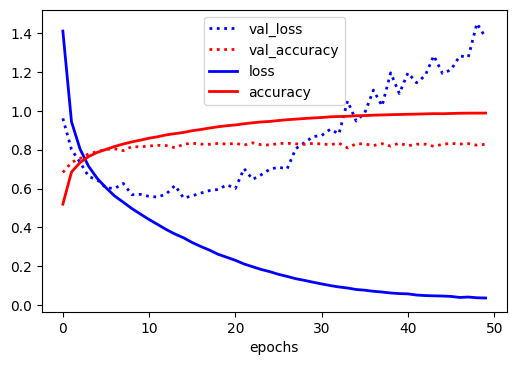

```
Model: "sequential_26"
_________________________________________________________________
Layer (type)                 Output Shape              Param #
=================================================================
vgg16 (Model)                (None, 1, 1, 512)         14714688
_________________________________________________________________
flatten_26 (Flatten)         (None, 512)               0
_________________________________________________________________
dense_51 (Dense)             (None, 256)               131328
_________________________________________________________________
dropout_13 (Dropout)         (None, 256)               0
_________________________________________________________________
dense_52 (Dense)             (None, 10)                2570
=================================================================
Total params: 14,848,586
Trainable params: 7,213,322
Non-trainable params: 7,635,264
_________________________________________________________________
None
def build_model_4_1():
  conv_base = VGG16(weights='imagenet', include_top=False, input_shape=(32,32,3))
  model = models.Sequential()
  model.add(conv_base)
  model.add(layers.Flatten())
  model.add(layers.Dense(256, activation='relu'))
  model.add(layers.Dropout(0.5))
  model.add(layers.Dense(10, activation='softmax'))
  for layer in conv_base.layers:
    if layer.name == 'block5_conv1' or layer.name == 'block5_conv2' or layer.name == 'block5_conv3':
      layer.trainable = True
    else:
      layer.trainable = False

  optimizer=tf.keras.optimizers.RMSprop(lr=2e-5)
  model.compile(optimizer=optimizer,
                loss='categorical_crossentropy',
                metrics=['accuracy'])
  return model
```

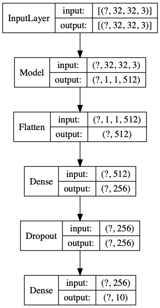

#### Answer 4.2, Embeddings (5p)

- Generate embeddings with the trained convolutional part of model_4_1 (without the dense layer)
- Embed the training and test data and store them to disk
- Build and evaluate a pipeline on the embedded data
  - Check if pipeline makes sense (e.g. use models that can handle many dimensions)
- Describe what you did and what you observed (max 800 chars).
  - Consider different models, preprocessing, tuning, etc.
  - Check performance (see original Submission.html) when in doubt. We did not run all the evaluations because it takes too long, and the output is ill-defined.

[output not shown]

```
Running time: 25.21 seconds
Last modified: May 26, 2020
scikit-learn version: 0.23.1
```